# Understanding Factors That Influence Insurance Charges

Sean Schilk

9/29/2025

This assignment focuses on bootstrapping the multiple regression model we identified in the last project. We use both bootstrap sampling methods to find the confidence intervals for regression coefficients.

```r
#last week's final model
insurance <- read_csv("https://sschilk.github.io/Topics-In-Advanced-Statistics/datasets/insurance.csv")
lambda=.11

final.data <- insurance %>%
  filter(region != "northwest")
table(final.data$region)
```

```
northeast southeast southwest
      324       364       325
```

```r
###
final.model = log.age.m = lm((charges)^lambda ~ log(age) + sex + bmi + children + smoker + region,
       data=final.data)
kable(summary(final.model)$coef, caption = "Inferential Statistics of Final Model")
```

Inferential Statistics of Final Model

|  | Estimate | Std. Error | t value | Pr(>\|t\|) |
| --- | --- | --- | --- | --- |
| (Intercept) | 1.2049013 | 0.0420070 | 28.683314 | 0.0000000 |
| log(age) | 0.3606297 | 0.0106560 | 33.842878 | 0.0000000 |
| sexmale | -0.0206241 | 0.0083140 | -2.480635 | 0.0132776 |
| bmi | 0.0047151 | 0.0006876 | 6.856938 | 0.0000000 |
| children | 0.0209350 | 0.0034097 | 6.139803 | 0.0000000 |
| smokeryes | 0.4925288 | 0.0101554 | 48.499199 | 0.0000000 |
| regionsoutheast | -0.0453653 | 0.0104500 | -4.341161 | 0.0000156 |
| regionsouthwest | -0.0370933 | 0.0103666 | -3.578162 | 0.0003625 |

# 1 Bootstrap

we use bootstrapping cases to find the confidence intervals for the coefficients in the final regression model

```r
# Fit model on original data
orig.mod = lm((charges)^lambda ~ log(age) + sex + bmi + children + smoker + region,
              data = final.data)

# Store coefficient names
coef.names = names(coef(orig.mod))

# Create bootstrap coefficient matrix
B=1000
num.p = dim(model.matrix(orig.mod))[2]   # number of parameters
samp.n = dim(model.matrix(orig.mod))[1]  # sample size
btr.mtrx = matrix(rep(0,6*B), ncol=num.p) # zero matrix to store boot coefs

coef.mtrx = matrix(NA, nrow = B, ncol = length(coef.names))
colnames(coef.mtrx) = coef.names

# Bootstrap loop
for(i in 1:B){

  # Bootstrap sample indices
  bootc.id = sample(1:samp.n, samp.n, replace = TRUE)

  # Fit model on bootstrap sample
  log.price.btc = lm((charges)^lambda ~ log(age) + sex + bmi + children + smoker + region,
                     data = final.data[bootc.id, ])

  # Extract coefficients
  temp.coef = coef(log.price.btc)

  # Store coefficients by matching names
  coef.mtrx[i, names(temp.coef)] = temp.coef
}
# case study code was struggling with our categorical variables
```

Then let’s define an R function to make histograms of the bootstrap regression coefficients

```r
boot.hist = function(cmtrx, bt.coef.mtrx, var.id, var.nm){
  ## bt.coef.mtrx = matrix for storing bootstrap estimates of coefficients
  ## var.id = variable ID (1, 2, ..., k+1)
  ## var.nm = variable name on the hist title, must be the string in the double quotes
  ## coefficient matrix of the final model
  ## Bootstrap sampling distribution of the estimated coefficients
  x1.1 <- seq(min(bt.coef.mtrx[,var.id]), max(bt.coef.mtrx[,var.id]), length=300 )
  y1.1 <- dnorm(x1.1, mean(bt.coef.mtrx[,var.id]), sd(bt.coef.mtrx[,var.id]))
  # height of the histogram - use it to make a nice-looking histogram.
  highestbar = max(hist(bt.coef.mtrx[,var.id], plot = FALSE)$density)
  ylimit <- max(c(y1.1,highestbar))
  hist(bt.coef.mtrx[,var.id], probability = TRUE, main = var.nm, xlab="",
       col = "azure1",ylim=c(0,ylimit), border="lightseagreen")
  lines(x = x1.1, y = y1.1, col = "red3")
  lines(density(bt.coef.mtrx[,var.id], adjust=2), col="blue")
  #legend("topright", c(""))
}
```

The following histograms of the bootstrap estimates of regression coefficients represent the sampling distributions of the corresponding estimates in the final model.

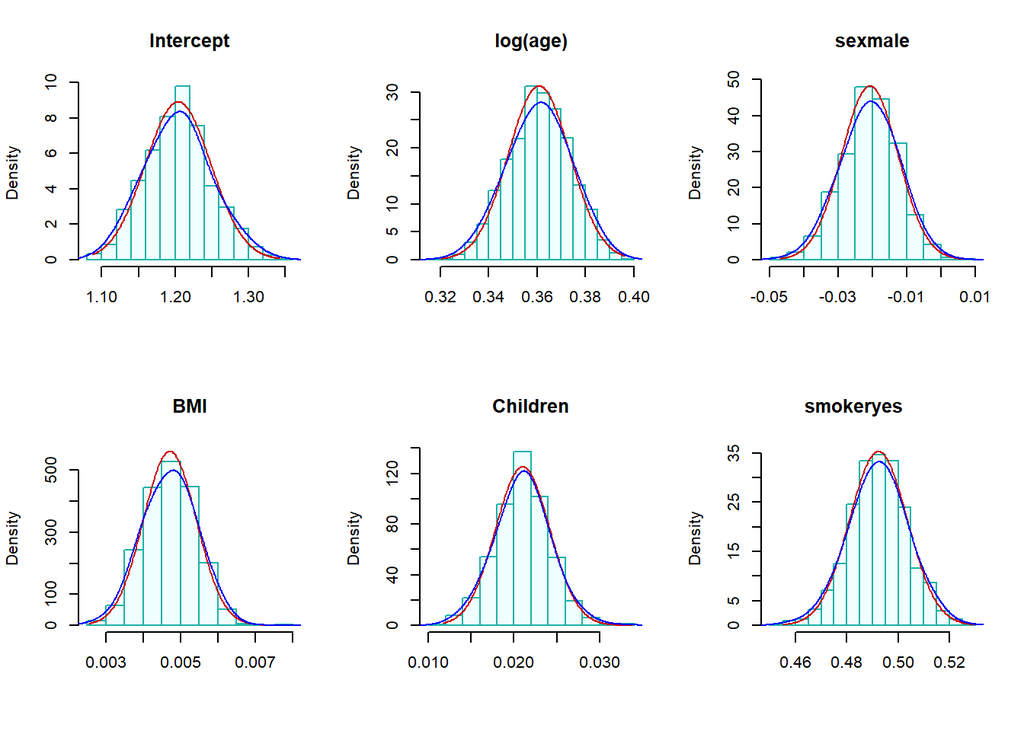

```r
par(mfrow=c(2,3))  # histograms of bootstrap coefs
boot.hist(bt.coef.mtrx=coef.mtrx, var.id=1, var.nm ="Intercept" )
boot.hist(bt.coef.mtrx=coef.mtrx, var.id=2, var.nm ="log(age)" )
boot.hist(bt.coef.mtrx=coef.mtrx, var.id=3, var.nm ="sexmale" )
boot.hist(bt.coef.mtrx=coef.mtrx, var.id=4, var.nm ="BMI" )
boot.hist(bt.coef.mtrx=coef.mtrx, var.id=5, var.nm ="Children" )
boot.hist(bt.coef.mtrx=coef.mtrx, var.id=6, var.nm ="smokeryes       " )
```

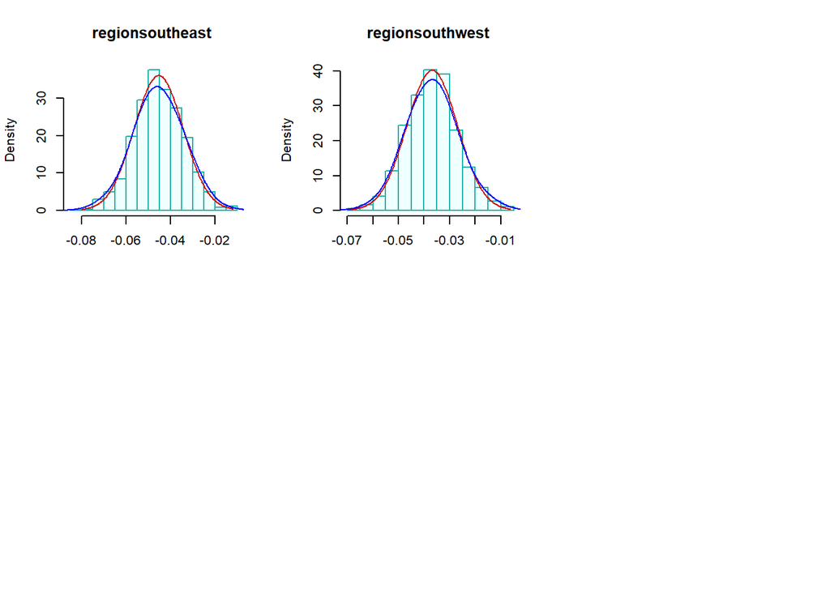

```r
boot.hist(bt.coef.mtrx=coef.mtrx, var.id=7, var.nm ="regionsoutheast " )
boot.hist(bt.coef.mtrx=coef.mtrx, var.id=8, var.nm ="regionsouthwest " )
```

We can see from the above histograms that the two density curves in all histograms are close to each other. we would expect that significance test results and the corresponding bootstrap confidence intervals are consistent. Next, we find 95% bootstrap confidence intervals of each regression coefficient and combined them with the output of the final model.

```r
num.p = dim(coef.mtrx)[2]  # number of parameters
btc.ci = NULL
btc.wd = NULL
for (i in 1:num.p){
  lci.025 = round(quantile(coef.mtrx[, i], 0.025, type = 2),8)
  uci.975 = round(quantile(coef.mtrx[, i],0.975, type = 2 ),8)
  btc.wd[i] =  uci.975 - lci.025
  btc.ci[i] = paste("[", round(lci.025,4),", ", round(uci.975,4),"]")
 }
#as.data.frame(btc.ci)
cmtrx <- summary(orig.mod)$coef

kable(as.data.frame(cbind(formatC(cmtrx,4,format="f"), btc.ci.95=btc.ci)),
      caption = "Regression Coefficient Matrix")
```

Regression Coefficient Matrix

|  | Estimate | Std. Error | t value | Pr(>\|t\|) | btc.ci.95 |
| --- | --- | --- | --- | --- | --- |
| (Intercept) | 1.2049 | 0.0420 | 28.6833 | 0.0000 | [ 1.1207 , 1.2961 ] |
| log(age) | 0.3606 | 0.0107 | 33.8429 | 0.0000 | [ 0.3352 , 0.3849 ] |
| sexmale | -0.0206 | 0.0083 | -2.4806 | 0.0133 | [ -0.037 , -0.005 ] |
| bmi | 0.0047 | 0.0007 | 6.8569 | 0.0000 | [ 0.0033 , 0.006 ] |
| children | 0.0209 | 0.0034 | 6.1398 | 0.0000 | [ 0.0147 , 0.0275 ] |
| smokeryes | 0.4925 | 0.0102 | 48.4992 | 0.0000 | [ 0.4697 , 0.5139 ] |
| regionsoutheast | -0.0454 | 0.0105 | -4.3412 | 0.0000 | [ -0.0679 , -0.0239 ] |
| regionsouthwest | -0.0371 | 0.0104 | -3.5782 | 0.0004 | [ -0.0563 , -0.0161 ] |

We can see from the above table of summarized statistics, the significance tests of regression coefficients based on the p-values and the corresponding 95% confidence intervals are consistent.

# 2 Bootstrap Residuals

The distribution of the residuals is depicted in the following histogram

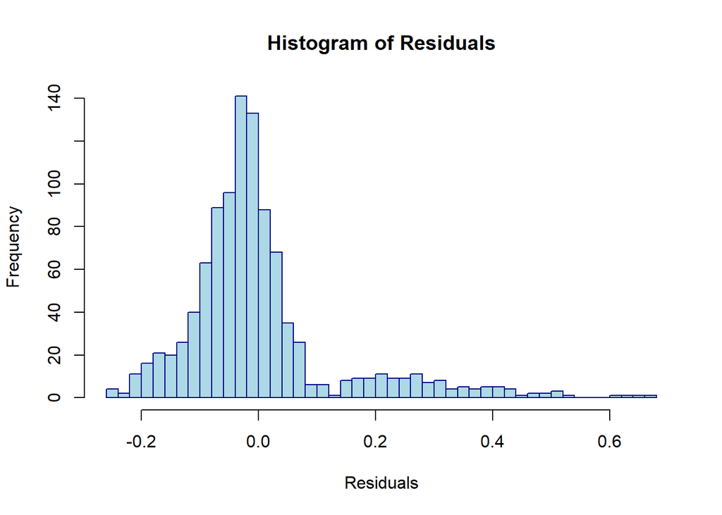

```r
hist(sort(orig.mod$residuals),n=40,
     xlab="Residuals",
     col = "lightblue",
     border="navy",
     main = "Histogram of Residuals")
```

There doesn’t seem to be any outliers, assuming the residuals are standardized. We do have a right skew distribution here.

# 3 Implementation of Residual Bootstrap Regression

The following code generates bootstrap confidence intervals of regression coefficients

```r
model.resid = orig.mod$residuals

B = 1000

num.p  = length(coef(orig.mod))   # number of coefficients
samp.n = nrow(final.data)

btr.mtrx = matrix(NA, nrow = B, ncol = num.p)
colnames(btr.mtrx) = names(coef(orig.mod))

for(i in 1:B){

  # Bootstrap residuals
  bt.resid = sample(model.resid,
                    size = samp.n,
                    replace = TRUE)

  # Bootstrap response
  bt.lg.price = fitted(orig.mod) + bt.resid

  # Put bootstrap response into data
  final.data$bt.lg.price = bt.lg.price

  # Refit model using bootstrap response
  btr.model = lm(bt.lg.price ~ log(age) + sex + bmi +
                   children + smoker + region,
                 data = final.data)

  # Store coefficients
  btr.mtrx[i, ] = coef(btr.model)
}
```

Next, I make histograms of the residual bootstrap estimates of the regression coefficients.

```r
boot.hist = function(bt.coef.mtrx, var.id, var.nm){
  ## bt.coef.mtrx = matrix for storing bootstrap estimates of coefficients
  ## var.id = variable ID (1, 2, ..., k+1)
  ## var.nm = variable name on the hist title, must be the string in the double quotes
  ## Bootstrap sampling distribution of the estimated coefficients
  x1.1 <- seq(min(bt.coef.mtrx[,var.id]), max(bt.coef.mtrx[,var.id]), length=300 )
  y1.1 <- dnorm(x1.1, mean(bt.coef.mtrx[,var.id]), sd(bt.coef.mtrx[,var.id]))
  # height of the histogram - use it to make a nice-looking histogram.
  highestbar = max(hist(bt.coef.mtrx[,var.id], plot = FALSE)$density)
  ylimit <- max(c(y1.1,highestbar))
  hist(bt.coef.mtrx[,var.id], probability = TRUE, main = var.nm, xlab="",
       col = "azure1",ylim=c(0,ylimit), border="lightseagreen")
  lines(x = x1.1, y = y1.1, col = "red3")       # normal density curve
  lines(density(bt.coef.mtrx[,var.id], adjust=2), col="blue")    # loess curve
}
```

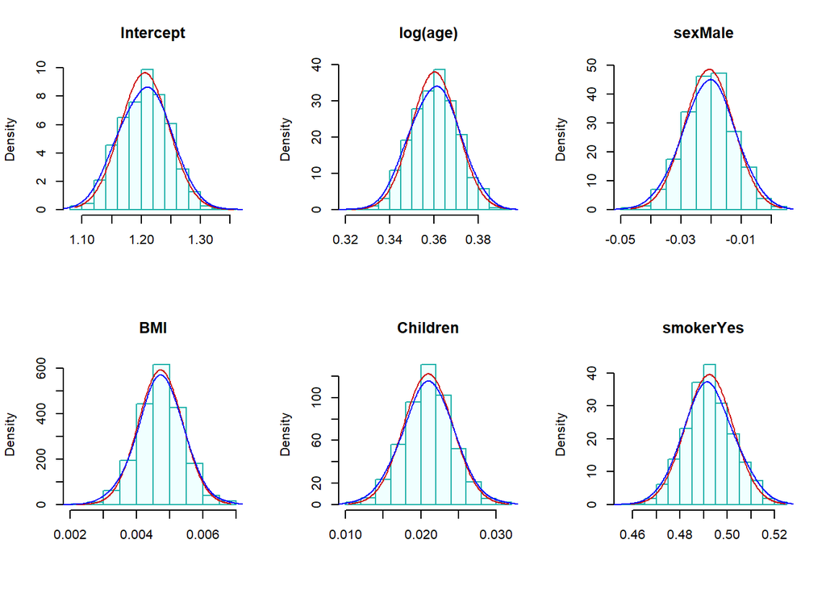

```r
par(mfrow=c(2,3))  # histograms of bootstrap coefs
boot.hist(bt.coef.mtrx=btr.mtrx, var.id=1, var.nm ="Intercept" )
boot.hist(bt.coef.mtrx=btr.mtrx, var.id=2, var.nm ="log(age)" )
boot.hist(bt.coef.mtrx=btr.mtrx, var.id=3, var.nm ="sexMale" )
boot.hist(bt.coef.mtrx=btr.mtrx, var.id=4, var.nm ="BMI" )
boot.hist(bt.coef.mtrx=btr.mtrx, var.id=5, var.nm ="Children" )
boot.hist(bt.coef.mtrx=btr.mtrx, var.id=6, var.nm ="smokerYes" )
```

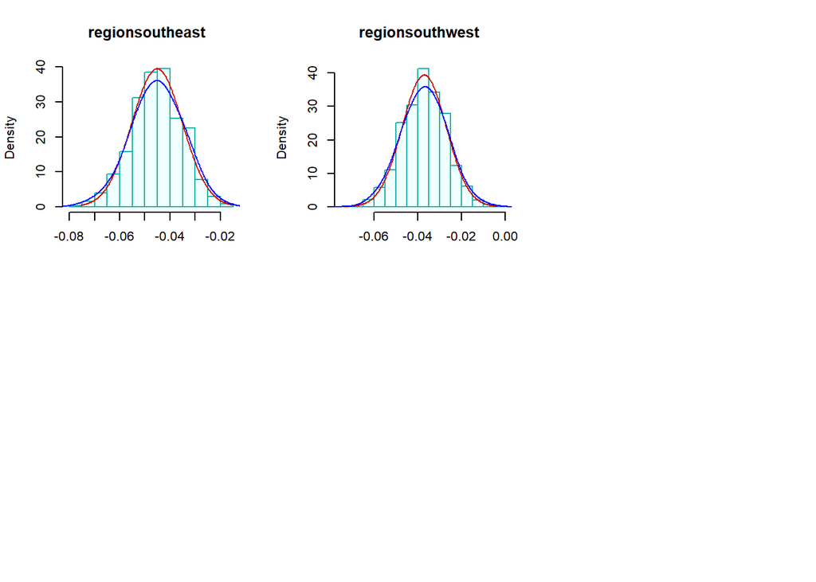

```r
boot.hist(bt.coef.mtrx=btr.mtrx, var.id=7, var.nm ="regionsoutheast  " )
boot.hist(bt.coef.mtrx=btr.mtrx, var.id=8, var.nm ="regionsouthwest  " )
```

The residual bootstrap sampling distributions of each estimated regression coefficient. The normal and LOESS curves are close to each other. This also indicated that the inference of the significance of variables based on p-values and residual bootstrap will yield the same results.

The 95% residual bootstrap confidence intervals are given in the following

```r
#
num.p = dim(coef.mtrx)[2]  # number of parameters
btr.ci = NULL
btr.wd = NULL
for (i in 1:num.p){
  lci.025 = round(quantile(btr.mtrx[, i], 0.025, type = 2),8)
  uci.975 = round(quantile(btr.mtrx[, i],0.975, type = 2 ),8)
  btr.wd[i] = uci.975 - lci.025
  btr.ci[i] = paste("[", round(lci.025,4),", ", round(uci.975,4),"]")
}
#as.data.frame(btc.ci)
kable(as.data.frame(cbind(formatC(cmtrx,4,format="f"), btr.ci.95=btr.ci)),
      caption = "Regression Coefficient Matrix with 95% Residual Bootstrap CI")
```

Regression Coefficient Matrix with 95% Residual Bootstrap CI

|  | Estimate | Std. Error | t value | Pr(>\|t\|) | btr.ci.95 |
| --- | --- | --- | --- | --- | --- |
| (Intercept) | 1.2049 | 0.0420 | 28.6833 | 0.0000 | [ 1.1265 , 1.2841 ] |
| log(age) | 0.3606 | 0.0107 | 33.8429 | 0.0000 | [ 0.3405 , 0.3812 ] |
| sexmale | -0.0206 | 0.0083 | -2.4806 | 0.0133 | [ -0.0377 , -0.005 ] |
| bmi | 0.0047 | 0.0007 | 6.8569 | 0.0000 | [ 0.0033 , 0.006 ] |
| children | 0.0209 | 0.0034 | 6.1398 | 0.0000 | [ 0.0146 , 0.0272 ] |
| smokeryes | 0.4925 | 0.0102 | 48.4992 | 0.0000 | [ 0.4719 , 0.5126 ] |
| regionsoutheast | -0.0454 | 0.0105 | -4.3412 | 0.0000 | [ -0.0662 , -0.0263 ] |
| regionsouthwest | -0.0371 | 0.0104 | -3.5782 | 0.0004 | [ -0.0578 , -0.0174 ] |

As expected, the residual bootstrap confidence intervals yield the same results as p-values do. This is because the sample size is large enough so that the sampling distributions of estimated coefficients have sufficiently good approximations of normal distributions.

# 4 Combine All Inferential Statistics

Finally, we put all inferential statistics in a single table so we can compare these results.

```r
kable(as.data.frame(cbind(formatC(cmtrx[,-3],4,format="f"), btc.ci.95=btc.ci,btr.ci.95=btr.ci)),
      caption="Final Combined Inferential Statistics: p-values and Bootstrap CIs")
```

Final Combined Inferential Statistics: p-values and Bootstrap CIs

|  | Estimate | Std. Error | Pr(>\|t\|) | btc.ci.95 | btr.ci.95 |
| --- | --- | --- | --- | --- | --- |
| (Intercept) | 1.2049 | 0.0420 | 0.0000 | [ 1.1207 , 1.2961 ] | [ 1.1265 , 1.2841 ] |
| log(age) | 0.3606 | 0.0107 | 0.0000 | [ 0.3352 , 0.3849 ] | [ 0.3405 , 0.3812 ] |
| sexmale | -0.0206 | 0.0083 | 0.0133 | [ -0.037 , -0.005 ] | [ -0.0377 , -0.005 ] |
| bmi | 0.0047 | 0.0007 | 0.0000 | [ 0.0033 , 0.006 ] | [ 0.0033 , 0.006 ] |
| children | 0.0209 | 0.0034 | 0.0000 | [ 0.0147 , 0.0275 ] | [ 0.0146 , 0.0272 ] |
| smokeryes | 0.4925 | 0.0102 | 0.0000 | [ 0.4697 , 0.5139 ] | [ 0.4719 , 0.5126 ] |
| regionsoutheast | -0.0454 | 0.0105 | 0.0000 | [ -0.0679 , -0.0239 ] | [ -0.0662 , -0.0263 ] |
| regionsouthwest | -0.0371 | 0.0104 | 0.0004 | [ -0.0563 , -0.0161 ] | [ -0.0578 , -0.0174 ] |

The above table shows that: - All three methods yield the same results in terms of the significance of individual explanatory variables. The reason is that the final working model does not have a serious violation of the model assumption.

```r
kable(round(cbind(btc.wd, btr.wd),4), caption="width of the two bootstrap confidence intervals")
```

width of the two bootstrap confidence intervals

| btc.wd | btr.wd |
| --- | --- |
| 0.1754 | 0.1577 |
| 0.0497 | 0.0408 |
| 0.0320 | 0.0326 |
| 0.0027 | 0.0027 |
| 0.0129 | 0.0127 |
| 0.0442 | 0.0406 |
| 0.0440 | 0.0399 |
| 0.0402 | 0.0404 |

We see from the above table that the widths of residual-bootstrap and case-bootstrap confidence intervals are similar to each other.

# 5 Model Reporting

We have used different methods to perform regression analysis. The inferential results of all three major methods yield similar results. We chose the parametric model to report.

```r
kable(cmtrx, caption = "Inferential Statistics of Final Model")
```

Inferential Statistics of Final Model

|  | Estimate | Std. Error | t value | Pr(>\|t\|) |
| --- | --- | --- | --- | --- |
| (Intercept) | 1.2049013 | 0.0420070 | 28.683314 | 0.0000000 |
| log(age) | 0.3606297 | 0.0106560 | 33.842878 | 0.0000000 |
| sexmale | -0.0206241 | 0.0083140 | -2.480635 | 0.0132776 |
| bmi | 0.0047151 | 0.0006876 | 6.856938 | 0.0000000 |
| children | 0.0209350 | 0.0034097 | 6.139803 | 0.0000000 |
| smokeryes | 0.4925288 | 0.0101554 | 48.499199 | 0.0000000 |
| regionsoutheast | -0.0453653 | 0.0104500 | -4.341161 | 0.0000156 |
| regionsouthwest | -0.0370933 | 0.0103666 | -3.578162 | 0.0003625 |

Regression coefficients explain the correlation between charges^lambda and the corresponding explanatory variables. We can interpret the regression coefficients of said explanatory variables.